# nilHMM sanity check paint: source × caller tracks, one engine, no Julia

- Show All Code
- Hide All Code
- View Source

Chromosome painting of the vary-skim sweep NILs (+B73 control) — 6 tracks = 2 data sources (Skim, BRB) crossed with nilHMM callers, all through the nilHMM package

Author

Fausto Rodríguez-Zapata

Published

July 2, 2026

**Context.** This is the cross-track sanity check for the unified `nilHMM` engine, where every caller runs through one duration-aware 3-state (REF/HET/ALT) HMM with the emission as the only swappable piece. We paint the same **vary-skim coverage-sweep NILs** (plus a clean B73 control) and eyeball whether the independent tracks agree on where the donor blocks are, and whether the control stays REF. Memory: `wideseq-chrpainting-code`, `generative_vs_discriminative_callers`, `cassini-googa-caller`, `method-naming-source-caller`, `skim-count-caller-calibration`, `rtiger-betabinomial-cost`.

**The six tracks are *not* six callers.** Each track is a combination of a **data source** and a **nilHMM caller method** (naming convention `<DataSource>-<Caller>`, source first — memory `method-naming-source-caller`). There are only **two data sources** and **four distinct callers**; Skim and BRB each run three tracks and *share* the nNIL and RTIGER callers:

- **Data sources (2):** `Skim` = low-coverage WGS; `BrB` = 3′ RNA-seq (BRB-seq).
- **Callers (4 distinct):** `binhmm` (Gaussian on per-bin `ALT_FREQ`), `nNIL` (count / BetaBinomial HMM), `RTIGER` (Julia-free port), `ATLAS` (GOOGA-shadow gene-level GT).

The tracks are ordered **first by data source, then by caller** (all three Skim tracks, then all three BRB tracks):

| # | Track | Data source | nilHMM caller | Input marker set |
| --- | --- | --- | --- | --- |
| 1 | **Skim-binhmm** | Skim (low-cov WGS) | `binhmm` — 3-state Gaussian on per-bin `ALT_FREQ`, REF anchored at the floor | **dense ~27.6 M-SNP set** — per-1 Mb `ALT_FREQ` `bin_genotypes` from GATK `CollectAllelicCounts` at the full teosinte-informative wideseq positions (mount, `bzeaseq/ancestry`) |
| 2 | **Skim-nNIL** | Skim (low-cov WGS) | `nNIL` — count / BetaBinomial HMM (`rrate=1e-4`, `err=0.01`) | **50K panel** counts (thinned SNP50K) |
| 3 | **Skim-rtiger** | Skim (low-cov WGS) | `RTIGER` port (`rigidity=5`) | **50K panel** counts (thinned SNP50K) |
| 4 | **BrB-nNIL** | BrB (3′ RNA-seq) | `nNIL` — count HMM, `fit_means` (`rrate=1e-8`) | **wideseq-thinned** BRB counts |
| 5 | **BrB-rtiger** | BrB (3′ RNA-seq) | `RTIGER` port (`rigidity=7`) | **wideseq-thinned** BRB counts |
| 6 | **BrB-atlas** | BrB (3′ RNA-seq) | `ATLAS` — GOOGA-shadow gene-level GT (`≥.95`/`≥.25`, min 5 reads) → geometric-duration HMM | cassini **pangene** counts, per donor species |

So the grid is 2 sources × 3 caller-slots = 6 tracks, drawing on 4 unique callers (`binhmm` is Skim-only, `ATLAS` is BRB-only, `nNIL`/`RTIGER` run on both).

**NoteMarker-set provenance — the tracks run at different SNP densities**

The three Skim tracks are **not** all on the same markers. **Skim-binhmm runs on the full dense set of ~27.6 M teosinte-informative SNPs** (2.0–4.0 M per chromosome; total 27,603,777), whereas **Skim-nNIL / Skim-rtiger run on the much sparser ~52 K “SNP50K” set**. These are two different marker sets with two different provenances:

- **The ~27.6 M panel** (`wideseq_ref`) is a **teosinte-informative SNP set** — positions where teosinte (the donor) carries variation relative to B73 (the recurrent parent), so a read there is diagnostic of donor-vs-recurrent ancestry. That informativeness is the whole point of the panel; it is a **reference/filter set, not sample genotypes**. It is built from the **Schnable et al. 2023** *Zea* pan-genome VCF by keeping the teosinte/*Tripsacum* + B73 samples and biallelic SNPs — the MAF ≥ 0.05 cutoff is merely the mechanism that selects the donor-informative (species-common) sites (`bzeaseq/get_variants_from_schnable2023.sh`). GATK `CollectAllelicCounts` tallies each skim/BRB sample’s reads at these positions — so the BRB count tracks (BrB-nNIL, BrB-rtiger) draw on the same panel; only Skim-binhmm keeps the full 27.6 M density.
- **The ~52 K SNP50K set is an *intersection* — not a genotyping array, and not merely a coarse thinning of the 27.6 M panel.** Its unfiltered base is the **ZEAL NIL BAMs → GATK joint genotyping (N. Tandukar) + Beagle imputation** (196,120 SNPs); intersecting those genotyped sites with the 27.6 M teosinte-informative panel yields **51,991 SNPs** (so the 50K is itself teosinte-informative, being a subset of the panel). The Skim-nNIL / Skim-rtiger counts are reads tallied at those ~52 K sites. Here the teosinte panel is the **filter** and the ZEAL genotyping is the base — full chain + paths in `sawers-rellan-labs/BzeaSeq` → `docs/donor_id_jaccard.md` (“SNP50K & marker-set provenance”).

The MAF ≥ 0.05 filter keeps donor-informative (species-common) sites, which raises the donor dose and widens REF/HET/ALT separation — see `genotype_likelihoods_and_hmm` §5 and `snp50k_genotype_identifiability` §2.1/§2.6/§3.

> **Parameters are illustrative, not fully re-calibrated.** This note is a coherence check across sources and callers, not a final call set.

# 1. Setup — engine, paths, samples

```r
suppressMessages({
  library(nilHMM)
  library(data.table)
  library(ggplot2)
})
# Inputs are staged locally under data/ by stage_sanity_check_paint.R (see DATA.md),
# organized by (source x input type); paths below point into that layout.
SS <- here::here("data/skimsweep") # the vary-skim cohort
SKIM <- file.path(SS, "skim") # skim counts (counts_50k/) + bins (bins/)
BRB <- file.path(SS, "brb") # brb counts (counts_wideseq/) + pangene (pangene/)
REF <- here::here("data/ref") # genome-level ATLAS gene maps

# samples: control + 10 vary-skim NILs (ordered by skim lambda)
mem <- fread(file.path(SS, "coverage_sweep_members.csv"))[sweep == "vary_skim"][order(vary_cov)]
mem[, tax := sub("\\..*", "", nil)]
tax2dir <- c(
  Zx = "mexicana", Zl = "luxurians", Zd = "diploperennis",
  Zv = "parviglumis", Zh = "huehuetenangensis"
)
mem[, adir := tax2dir[tax]]
# wrapped left-hand label: cov + FULL pedigree string, then skim/brb plate ids
wraplab <- function(cov, ped, skim, brb) sprintf("%s\n%s\nskim:%s\nbrb:%s", cov, ped, skim, brb)
rows <- rbind(
  data.table(
    rowlab = wraplab("B73 ctrl", "B73 (control)", "PN10_SID893", "PN3_SID213"),
    skim = "PN10_SID893", brb = "PN3_SID213", adir = "mexicana"
  ),
  mem[, .(
    rowlab = wraplab(sprintf("%.2f×", vary_cov), nil, skim_name, brb_name),
    skim = skim_name, brb = brb_name, adir
  )]
)
```

# 2. ATLAS: competitive-mapping ancestry (GOOGA-shadow)

**ATLAS** = **A**ncestry by **T**ranscript-**L**evel **A**lignment **S**cores.

**The basic principle is competitive mapping: count the reads that match each founder genome.** Where the SNP-panel callers read an *allele fraction* at predefined variant sites, ATLAS instead aligns each transcript read against **both founder references at once** — B73 (the recurrent parent) and the teosinte **donor** transcriptome — and lets the **alignment scores** decide which parent that read came from. Per read, the best alignment score (with a margin `k` on the score gap `ΔAS`) votes the read as **REF**, **DONOR**, or **AMBIGUOUS**. A read that maps equally well to both parents landed on sequence that is *identical* between them (conserved — at ~2 % B73-vs-donor divergence this is ~98 % of positions), so it carries no ancestry information: **AMBIGUOUS = non-informative → dropped** (it is *not* a HET call). Summing the informative votes over a gene gives the two competitive-mapping counts, `n_recur` (B73-matching reads) and `n_donor` (donor-matching reads); ancestry is then just “which founder’s genome captured the reads at this gene.”

**Caveat — the “donor” reference is a species-level stand-in, not the actual donor accession.** We do not have the genome/transcriptome of the specific teosinte accession used in each cross, so the donor side of the competitive alignment is a **representative reference for the donor’s species** (per `tax2dir`: mexicana, luxurians, diploperennis, parviglumis, huehuetenangensis). A read is scored donor-vs-B73 against that proxy, not against the true parent — the same reference-data gap as the SNP-panel accession ceiling (`snp50k_genotype_identifiability` §2.6): sequence the accession carries but the species proxy lacks (or vice versa) is mis-scored, so `n_donor` is only as good as the stand-in’s match to the real donor.

**GOOGA is the template.** GOOGA (Fishman lab, *PLoS Genet* 2024, pgen.1011072) is a *Mimulus* F2 genetic-map-building pipeline whose ancestry step is **threshold-then-HMM**. ATLAS is a “GOOGA-shadow”: it ports that step onto the shared nilHMM engine —

1. **Per-gene hard call from the count fractions** (GOOGA `s2.py`, verbatim): `n_recur + n_donor < 5` → missing; recurrent fraction `≥ 0.95` → **REF** (AA); donor fraction `≥ 0.95` → **ALT / donor-hom** (BB); *both* parents `≥ 0.25` → **HET** (AB); otherwise missing. (Thresholds `0.95` / `0.25`, min 5 reads.)
2. **Place each gene at its B73 coordinate** and order it along the chromosome.
3. **Smooth with the engine’s categorical genotype-error (`gt`) emission + geometric-duration HMM** — the same duration/rigidity layer as every other caller, but a *categorical confusion* emission instead of count/BetaBinomial.

Why categorical and not a count model: these are **3′ RNA (BRB-seq) reads**, so a gene’s read depth is driven by **expression**, not coverage, and **allele-specific expression** pushes a true HET’s donor fraction off 0.5 — both confound a count/BetaBinomial emission. Discretizing to a hard genotype *first* (exactly what GOOGA, itself an eQTL/ASE pipeline, does) makes the emission **expression-agnostic**. Memory: `cassini-googa-caller`, `feedback-reproduce-from-source`.

The code below is the consumer-side staging: read the cassini pangene counts per donor species, apply the GOOGA hard call, map genes to B73 coordinates, and decode each chromosome through the `gt`-emission geometric-duration HMM.

```r
g2p <- fread(file.path(REF, "gene_to_pangene.tsv"))[species == "B73", .(gene, pan_gene)]
co <- fread(file.path(REF, "b73_gene_coords.tsv"),
  header = FALSE,
  col.names = c("gene", "chr", "start", "end")
)
gmap <- merge(g2p, co, by = "gene")
gmap[, chr := as.integer(sub("chr", "", chr))]
gmap <- unique(gmap[!is.na(chr)], by = "pan_gene")[, .(pan_gene, chr, pos = end)]
# The GOOGA hard-call (`≥.95`/`≥.25`, min 5 reads) + gt/geometric-duration HMM
# are the packaged ATLAS caller (`call_ancestry(caller = "atlas")`). Here we do
# only the consumer-side staging — read pangene counts, map to B73 gene
# coordinates — and hand the engine `(name, chr, pos, n_ref = recurrent,
# n_alt = donor)`. `rrate = 1e-3` matches the geometric duration used originally.
atlas_seg <- function(brb, adir) {
  f <- file.path(BRB, "pangene", adir, paste0(brb, ".pangene_counts.tsv"))
  if (!file.exists(f)) {
    return(NULL)
  }
  ct <- merge(fread(f), gmap, by = "pan_gene")[order(chr, pos)]
  seg <- as.data.table(call_ancestry(
    ct[, .(name = brb, chr, pos, n_ref = n_recur, n_alt = n_donor)],
    caller = "atlas", design = "BC2S3", rrate = 1e-3
  ))
  seg[, .(chr, start_bp, end_bp, state)]
}
```

# 3. binhmm (corrected) on the dense skim bins

3-state **Gaussian**-emission HMM on per-bin `ALT_FREQ`, porting the nilhifi `chromosome_painting.R` fix: REF is **anchored at the baseline floor** (mean fixed, sd from the low bins) so REF noise stays REF; HET/ALT are seeded from the data and refined by hard-EM with REF fixed; sticky transitions + design start priors + collapse guards. This replaces the free K=3 GMM (which always invents a 3rd cluster → HET over-call).

```r
# The anchored 3-state Gaussian HMM is the packaged `binhmm` gauss backend. Our
# input is the pre-computed per-1 Mb `bin_genotypes.tsv` (ALT_FREQ over the dense
# ~27.6 M set); `call_ancestry(caller = "binhmm")` accepts a pre-binned table (an
# `alt_freq` column + `start_bp`/`end_bp`, `pos` as the bin order key) and runs
# the HMM directly, with no re-binning.
binhmm_gauss <- function(skim, design = "BC2S2") {
  f <- file.path(SKIM, "bins", paste0(skim, "_bin_genotypes.tsv"))
  if (!file.exists(f)) {
    return(NULL)
  }
  d <- fread(f)
  obs <- data.table(
    name = skim, chr = as.integer(sub("chr", "", d$CONTIG)), pos = d$BIN_POS,
    alt_freq = d$ALT_FREQ, start_bp = d$BIN_START, end_bp = d$BIN_END
  )
  seg <- as.data.table(call_ancestry(obs, caller = "binhmm", design = design))
  seg[, .(chr, start_bp, end_bp, state)]
}
```

# 4. Count / RTIGER via the engine

**nNIL and RTIGER are the same engine, different duration.** Both are count-emission callers: they read per-SNP allele counts and score each marker with the count / BetaBinomial emission through the *one* `nilHMM` engine. The only thing that separates them is the duration layer — **nNIL** uses a **geometric** duration (a free per-marker switch probability), **RTIGER** a **rigidity** layer (an integer minimum run length). So both are just `call_ancestry(read_counts(path), caller = …)` with different arguments; there is no separate RTIGER program and no Julia.

**The duration knob has a distinct name per caller** (no overloaded `r`): `caller = "nnil"` takes **`rrate`**, the expected per-marker *recombination rate* of the geometric duration (Holland’s nNIL calibrates it as `2·total_cM / (100·n_markers)` ≈ `30/n_markers` for a 1500 cM maize map, and it is tunable from data by KS-vs-sim); `caller = "rtiger"` takes **`rigidity`**, the integer minimum run length (e.g. `5`). (`nilHMM`’s rigidity *duration* also has an exit rate `xrate`, but the faithful RTIGER port doesn’t use it.) The four count tracks below (Skim-nNIL, Skim-RTIGER, BrB-nNIL, BrB-RTIGER) differ only in caller, design prior, and these knobs — assembled in §5.

`eng()` is the thin adapter that wires a count file into the engine: locate and read the counts, decode through `call_ancestry()`, and hand back just the four columns the paint needs.

```r
# Locate a sample's count TSV under `dir`. Recursive because NILs and the B73
# control may sit in different subfolders; returns NA if the sample isn't staged.
find1 <- function(dir, s) {
  f <- list.files(dir, paste0("^", s, "\\.tsv$"), full.names = TRUE, recursive = TRUE)
  if (length(f)) f[1] else NA
}
# Read a count file and decode it through the shared engine with the caller +
# params in `...` (caller, design, rrate (nnil) / rigidity (rtiger), err, …).
# Keep only the paint's 4 columns; return NULL — skipped, not fatal — if the
# file is missing, so one absent sample never aborts the sweep.
eng <- function(path, ...) {
  if (is.na(path) || !file.exists(path)) {
    return(NULL)
  }
  seg <- as.data.table(call_ancestry(read_counts(path), ...))
  seg[, .(chr, start_bp, end_bp, state)]
}
SK50 <- file.path(SKIM, "counts_50k") # skim 50K-panel counts   (Skim-nNIL, Skim-RTIGER)
BRBW <- file.path(BRB, "counts_wideseq") # BRB wideseq-thinned counts (BrB-nNIL, BrB-RTIGER)
```

# 5. Assemble all tracks

```r
methods <- c(
  "Skim-binhmm", "Skim-nNIL", "Skim-rtiger",
  "BrB-nNIL", "BrB-rtiger", "BrB-atlas"
)

# run a caller, returning NULL (with a message) instead of aborting on error
grab <- function(fn) {
  tryCatch(fn, error = function(e) {
    message("  ! ", conditionMessage(e))
    NULL
  })
}

all <- list()
for (i in seq_len(nrow(rows))) {
  rl <- rows$rowlab[i]
  sk <- rows$skim[i]
  br <- rows$brb[i]
  ad <- rows$adir[i]

  sk_counts <- find1(SK50, sk) # skim 50K panel counts
  brb_counts <- file.path(BRBW, paste0(br, ".tsv")) # wideseq-thinned BRB counts

  tr <- list(
    `Skim-binhmm` = grab(binhmm_gauss(sk)),
    `Skim-nNIL` = grab(eng(sk_counts,
      caller = "nnil", design = "BC2S2", rrate = 1e-4, err = 0.01
    )),
    `Skim-rtiger` = grab(eng(sk_counts, caller = "rtiger", rigidity = 5L)),
    `BrB-nNIL` = grab(eng(brb_counts,
      caller = "nnil", design = "BC2S3", rrate = 1e-8, fit_means = TRUE
    )),
    `BrB-rtiger` = grab(eng(brb_counts, caller = "rtiger", rigidity = 7L)),
    `BrB-atlas` = grab(atlas_seg(br, ad))
  )

  # keep the non-empty tracks, tagging each with its row label and method
  for (m in names(tr)) {
    if (!is.null(tr[[m]]) && nrow(tr[[m]])) {
      all[[length(all) + 1L]] <- tr[[m]][, `:=`(rowlab = rl, method = m)]
    }
  }
}
df <- rbindlist(all)
df[, .N, by = method]
```

```
        method     N
        <char> <int>
1: Skim-binhmm   231
2:   Skim-nNIL   290
3: Skim-rtiger   265
4:    BrB-nNIL   223
5:  BrB-rtiger   329
6:   BrB-atlas   290
```

# 6. Paint

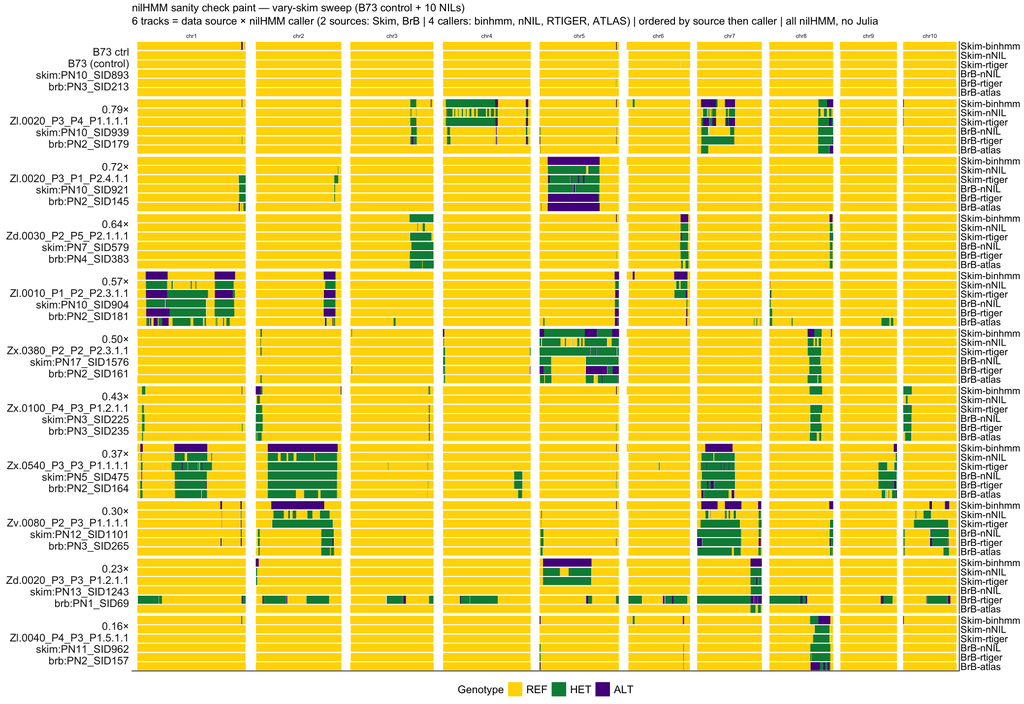

```r
yb <- data.table(method = methods, k = 5:0) # top -> bottom
df <- merge(df, yb, by = "method")
df[, `:=`(ylo = k / 6 + 0.01, yhi = (k + 1) / 6 - 0.01)]
# B73 ctrl on top, then skim-cov descending (facet switch = 'y')
df[, rowlab := factor(rowlab, levels = c(rows$rowlab[1], rev(rows$rowlab[-1])))]
df[, chr := factor(chr, levels = 1:10, labels = paste0("chr", 1:10))]
df[, state := factor(state, 0:2, c("REF", "HET", "ALT"))]
pal <- c(REF = "gold", HET = "springgreen4", ALT = "purple4")
p <- ggplot(df, aes(xmin = start_bp / 1e6, xmax = end_bp / 1e6, ymin = ylo, ymax = yhi, fill = state)) +
  geom_rect() +
  facet_grid(rowlab ~ chr, scales = "free_x", space = "free_x", switch = "y") +
  scale_fill_manual(values = pal, drop = FALSE) +
  scale_y_continuous(
    breaks = (5:0) / 6 + 1 / 12, labels = methods, position = "right",
    expand = expansion(mult = 0.01)
  ) +
  labs(
    title = "nilHMM sanity check paint — vary-skim sweep (B73 control + 10 NILs)",
    subtitle = "6 tracks = data source × nilHMM caller (2 sources: Skim, BrB | 4 callers: binhmm, nNIL, RTIGER, ATLAS) | ordered by source then caller | all nilHMM, no Julia",
    x = "Position (Mb)", fill = "Genotype"
  ) +
  ggpubr::theme_classic2(base_size = 8) +
  theme(
    plot.title = element_text(size = 12),
    plot.subtitle = element_text(size = 12),
    legend.position = "bottom",
    legend.text = element_text(size = 12),
    legend.title = element_text(size = 12),
    panel.spacing.x = unit(0.04, "lines"),
    panel.spacing.y = unit(0.15, "lines"),
    strip.background = element_blank(),
    strip.text.y.left = element_text(
      angle = 0, hjust = 1, size = 12, lineheight = 0.9
    ),
    axis.text.y.right = element_text(size = 11),
    axis.ticks.y = element_blank(),
    axis.title.x = element_blank(),
    axis.text.x = element_blank(),
    axis.ticks.x = element_blank()
  )
dir.create(here::here("results"), showWarnings = FALSE)
ggsave(here::here("results/nilhmm_sanity_check_paint.png"), p, width = 16, height = 11, dpi = 130, limitsize = FALSE)
fwrite(df, here::here("results/nilhmm_sanity_check_paint_segments.tsv"), sep = "\t")
p
```

# 7. Sanity read

- **The anchor holds:** the B73 control (top row) is essentially all-REF across all six tracks — a clean control paints clean.
- **NILs show localized donor blocks that broadly agree across callers.** The major introgressions land in the same chromosomes across independent callers and across the two data sources — the core sanity result.
- **Caller-specific behavior, as expected:** Skim-binhmm paints the broadest blocks and is more permissive toward ALT; BrB-rtiger is the noisiest (the known BRB-RTI RNA false-donor floor); BrB-atlas and BrB-nNIL are the most conservative.